# Results for CKMR manuscript 07/01/2022

Hi Lisa, These are the updated results as of 07/01/2022. My aim is to have Objective 3 (sensitivity to life history) completed by the end of next week (7/10), and to tackle Objective 4 (aging error) the following week (results by 7/17).

I know that these figures would benefit from a lot of tweaks to the formatting; I figure I’ll start getting into those details (e.g. pulling into Illustrator to clean up) once we know what figures we want to include. At that point I can also start sharing the figures and results section in a different way (e.g. not just through markdown). So please forgive small differences in font or size within/among the plots; I know there are a lot of them :)

Thanks a lot!  
John

## Results

### Objective 1: Model construction and validation

*Model validation* (first paragraph may be duplicative of Methods …) To initially validate our model, we sampled 1% of the population over four years and targeted sampling to the young-of-year portion of the population only. We assumed a scenario where adult survival and population growth are known with a 10% and 1% CV respectively and compared these results with a data-limited scenario where survival and population growth rate were unknown (Fig 1). For the data-limited scenario, we compared two distinct methods of setting a diffuse prior on lambda: one where lambda was given a uniform prior bound between 0.95 and 1.05, and one where lambda was iteratively fixed to 0.95, 1.0, and 1.05 as per Hillary et. al. (2018). In the latter scenario, the MCMC chains from all three trials were combined and analyzed together, both in situations with stable population growth (Fig 1) and also in scenarios where the population was allowed to increase or decrease over time (Fig S1).

Instances with informed priors on lambda and survival gave unbiased estimates for males and females, while instances with diffuse priors tended to have a slight negative skew for abundance (Fig 1A, B), which was worst in the scenario in which lambda was iteratively fixed. All scenarios showed a slight positive skew for survival (Fig 1C), which is expected under this sampling scheme that only includes four cohorts and therefore four years over which to estimate survival. The CVs on all parameters were smallest when we had ample prior data to inform survival and population growth (Fig 1D), as expected. In the data-limited scenario, the CV was slightly improved by using a uniform prior for population growth relative to iteratively fixing population growth to three values. Combined, these results demonstrate that our CKMR model can reliably estimate abundance when data are available to set informed priors on survival and population growth, and performs well in a data-limited scenario (though we’d recommend interpreting results in light of the credible intervals, rather than point estimates).

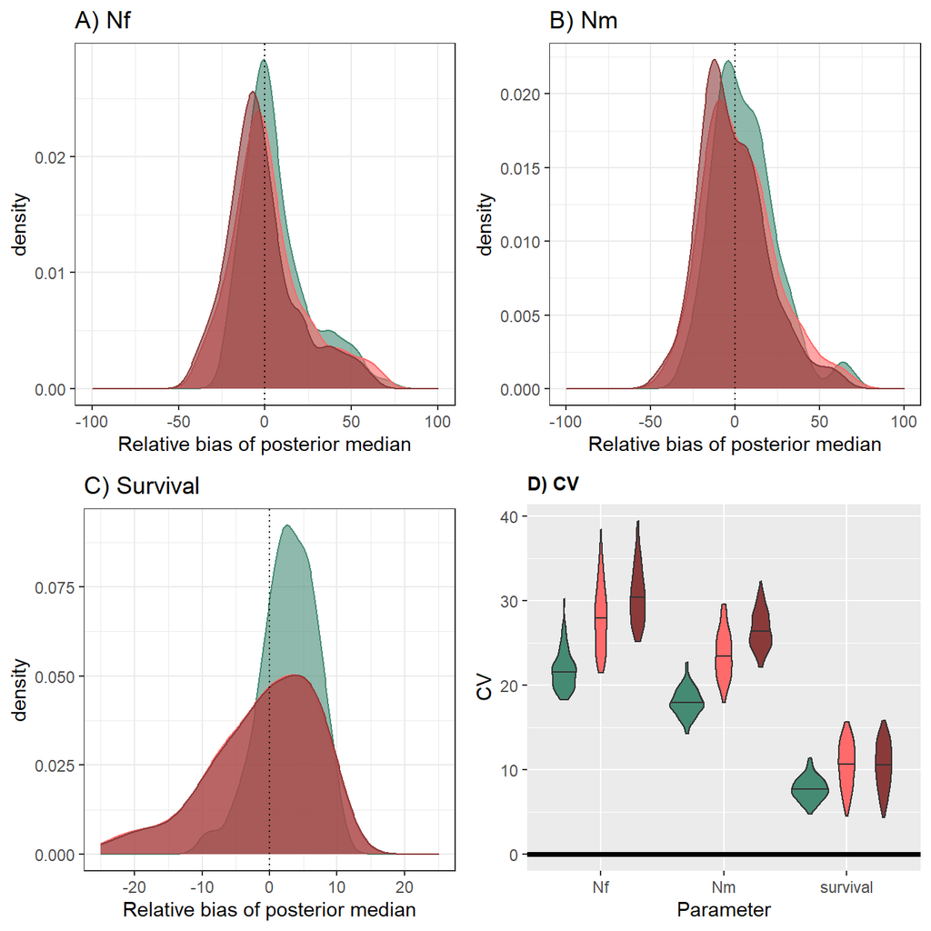

**Figure 1:** Model validation. **A-C** Density plot showing the relative bias of the posterior medians for female abundance (A), male abundance (B) and adult survival (C) after simulating 100 populations and fitting a CKMR model to samples from each. **D)** Violin plot showing CVs for each parameter and prior.

———————————————————————————————-

### Objective 2: Assess model performance in stochastic populations with uncertain vital rates.

*Sample size*  
Following model validation, we sought to assess how bias and precision vary depending on sampling selectivity and intensity. The model produced unbiased estimates for female (Fig 2A) and male (Fig 2B) abundance in most scenarios, with spread decreasing with increased sample size. Interestingly, we note that bias is smallest when 1% or 1.5% of the population is sampled. These sampling intensities correspond to about 50-150 kin pairs detected (Fig S2), which is the recommended target for CKMR (Bravington et. al. 2016). When 0.5% of the population was sampled, we typically found fewer than 25 kin pairs, which can explain the large CV associated with parameter estimates. When 2% of the population is sampled, the posterior medians are more likely to be biased, which we expect arises from having a very high number of kin pairs relative to the population size (Fig S2). Non-sparse sampling is expected to cause bias in parameter estimates with CKMR if the assumption of independence among samples is violated, as we expect is the case here. In such instances, downsampling to reduce the number of kin pairs to ~50-100 will improve bias at the expense of precision. Survival estimates (Fig 2C) tended to be positively biased under targeted sampling of young-of-year (red), but that bias disappeared when more age classes were included. Further, the addition of multiple cohorts greatly reduced the CV for all parameter estimates relative to targeted sampling of young-of-year (Fig 2D). Taken together, these results suggest that CKMR can give reasonable estimates of abundance under all sampling scenarios, but estimates of survival are unlikely to be reliable if few cohorts are included. Including multiple cohorts in sampling efforts improves both bias and precision of CKMR parameter estimates, and allows for more reliable estimates of survival.

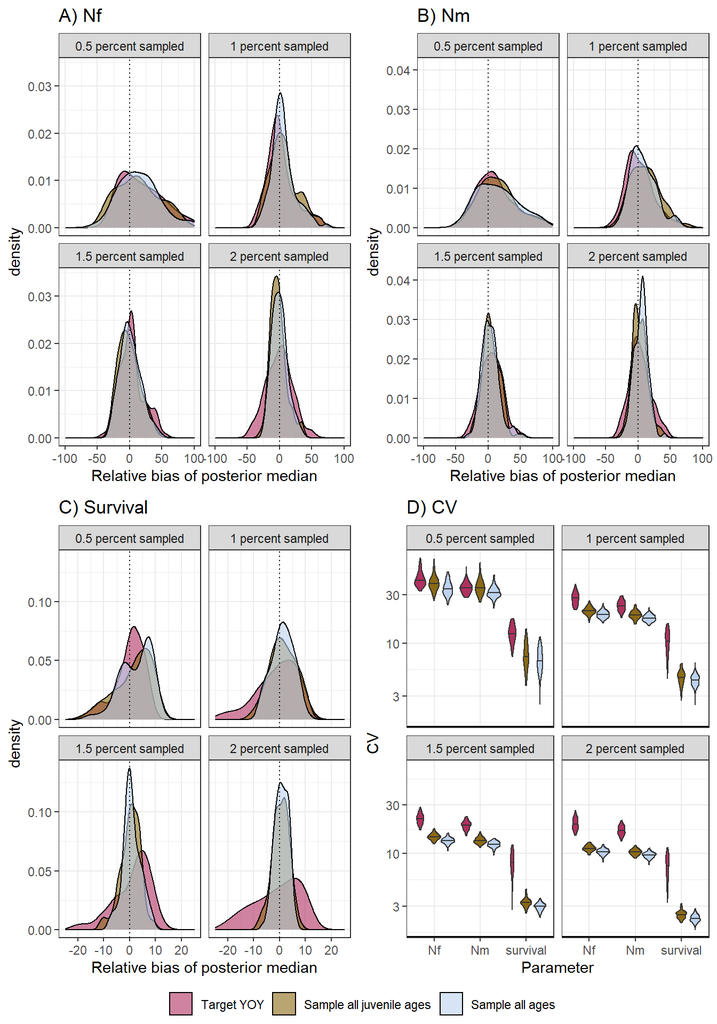

### Supplementary material

———————————————————————————————-

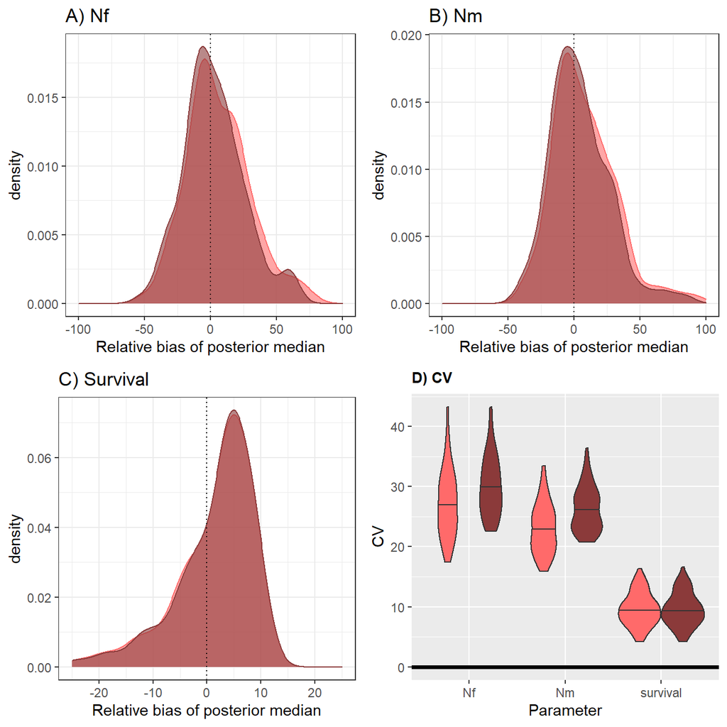

**Figure S1:** Model performance with diffuse priors with an increasing or declining population.

———————————————————————————————-

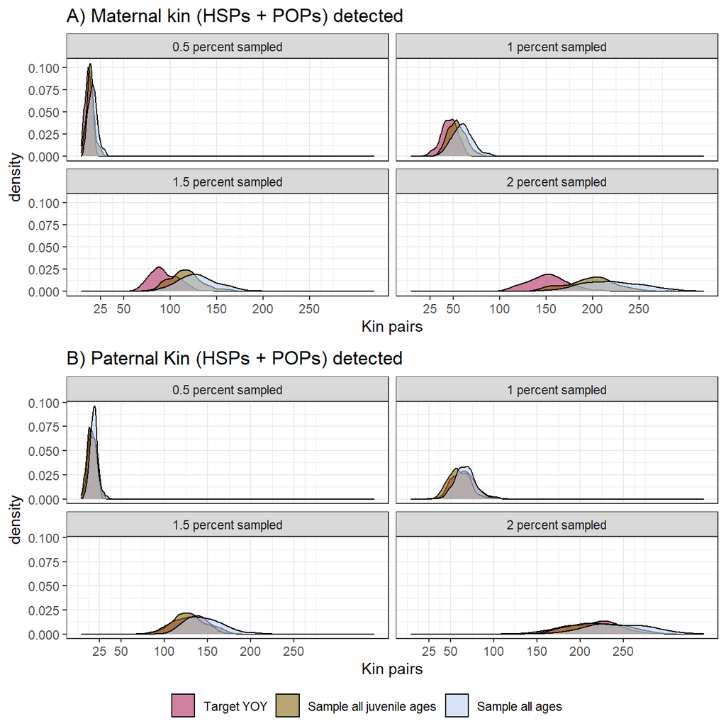

**Figure S2:** Kin pairs detected by sampling scheme.

———————————————————————————————-

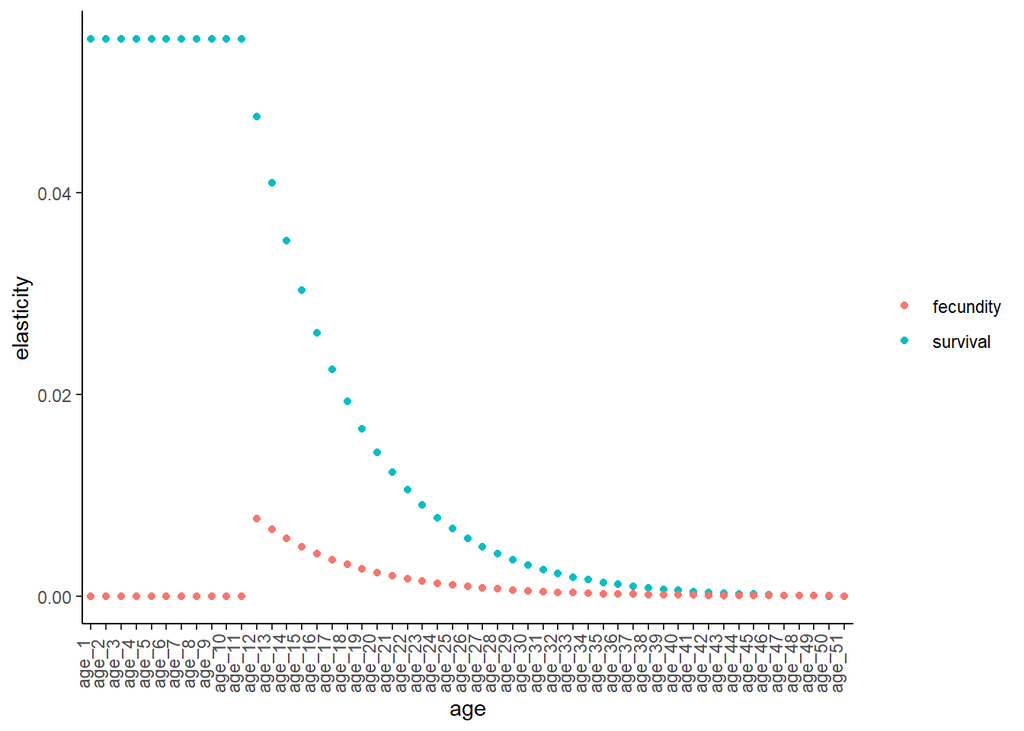

**Figure S3:** Elasticity analysis of lemon shark vital rates, showing that population growth is most sensitive to juvenile survival and fecundity at younger mature age classes.